> **Tip**: Welcome to the Investigate a Dataset project! You will find tips in quoted sections like this to help organize your approach to your investigation. Before submitting your project, it will be a good idea to go back through your report and remove these sections to make the presentation of your work as tidy as possible. First things first, you might want to double-click this Markdown cell and change the title so that it reflects your dataset and investigation.

# Project: Analysis on data : No show appointments

- Introduction
- Data Wrangling
- Exploratory Data Analysis
- Conclusions

## Introduction

> **Tip**: I have taken no-show-appointment dataset.This dataset includes various features which can help us identify whether a patient turned up for an appointment or not.In this project I will be analysing various factors that help us determine whether a patient will turn up for the appointment or not.This depends on various factors such as disease from which the patient is suffering or whether the patient has availed scholarship or not. In this project I will be taking few of the features into account and anaylsing them. I have taken diseases from which the patient is suffering, age and gender and the sms_recieved as the basis for investigation of my dataset

```python
import pandas as pd
import matplotlib.pyplot as plt
import numpy as np
import seaborn as sns
% matplotlib inline
```

## Data Wrangling

> In this section of the code, we will load in the data, check for cleanliness, and then trim and clean our dataset for analysis.

```python
df=pd.read_csv('noshowappointments.csv')
df.head()
```

|  | PatientId | AppointmentID | Gender | ScheduledDay | AppointmentDay | Age | Neighbourhood | Scholarship | Hipertension | Diabetes | Alcoholism | Handcap | SMS_received | No-show |
| --- | --- | --- | --- | --- | --- | --- | --- | --- | --- | --- | --- | --- | --- | --- |
| 0 | 2.987250e+13 | 5642903 | F | 2016-04-29T18:38:08Z | 2016-04-29T00:00:00Z | 62 | JARDIM DA PENHA | 0 | 1 | 0 | 0 | 0 | 0 | No |
| 1 | 5.589980e+14 | 5642503 | M | 2016-04-29T16:08:27Z | 2016-04-29T00:00:00Z | 56 | JARDIM DA PENHA | 0 | 0 | 0 | 0 | 0 | 0 | No |
| 2 | 4.262960e+12 | 5642549 | F | 2016-04-29T16:19:04Z | 2016-04-29T00:00:00Z | 62 | MATA DA PRAIA | 0 | 0 | 0 | 0 | 0 | 0 | No |
| 3 | 8.679510e+11 | 5642828 | F | 2016-04-29T17:29:31Z | 2016-04-29T00:00:00Z | 8 | PONTAL DE CAMBURI | 0 | 0 | 0 | 0 | 0 | 0 | No |
| 4 | 8.841190e+12 | 5642494 | F | 2016-04-29T16:07:23Z | 2016-04-29T00:00:00Z | 56 | JARDIM DA PENHA | 0 | 1 | 1 | 0 | 0 | 0 | No |

```python
# number of rows and columns in the dataset
df.shape
```

```
(110527, 14)
```

### DATA CLEANING PROCESS

```python
df.info()
```

```
<class 'pandas.core.frame.DataFrame'>
RangeIndex: 110527 entries, 0 to 110526
Data columns (total 14 columns):
PatientId         110527 non-null float64
AppointmentID     110527 non-null int64
Gender            110527 non-null object
ScheduledDay      110527 non-null object
AppointmentDay    110527 non-null object
Age               110527 non-null int64
Neighbourhood     110527 non-null object
Scholarship       110527 non-null int64
Hipertension      110527 non-null int64
Diabetes          110527 non-null int64
Alcoholism        110527 non-null int64
Handcap           110527 non-null int64
SMS_received      110527 non-null int64
No-show           110527 non-null object
dtypes: float64(1), int64(8), object(5)
memory usage: 11.8+ MB
```

- As you can see from the above results there are no NULL values in the dataset. But the datatypes of some colums are incorrect . So we will correct them

  ```
   a) ScheduledDay and AppointmentDay will be changed to datettime
   b) Some typing errors in the column names will also be corrected.
  ```

```python
# changing the datatypes of the columns
df['ScheduledDay'] = pd.to_datetime(df['ScheduledDay'])
df['AppointmentDay'] = pd.to_datetime(df['AppointmentDay'])

# Rename incorrect column names.
df = df.rename(columns={'Handcap': 'Handicap', 'No-show': 'NoShow','Hipertension': 'Hypertension'})
```

```python
df.head(1)
df.info()
```

```
<class 'pandas.core.frame.DataFrame'>
RangeIndex: 110527 entries, 0 to 110526
Data columns (total 14 columns):
PatientId         110527 non-null float64
AppointmentID     110527 non-null int64
Gender            110527 non-null object
ScheduledDay      110527 non-null datetime64[ns]
AppointmentDay    110527 non-null datetime64[ns]
Age               110527 non-null int64
Neighbourhood     110527 non-null object
Scholarship       110527 non-null int64
Hypertension      110527 non-null int64
Diabetes          110527 non-null int64
Alcoholism        110527 non-null int64
Handicap          110527 non-null int64
SMS_received      110527 non-null int64
NoShow            110527 non-null object
dtypes: datetime64[ns](2), float64(1), int64(8), object(3)
memory usage: 11.8+ MB
```

```python
df.duplicated().sum() # Finding out if any duplicate rows are there
```

```
0
```

```python
df.isnull().sum() # finding out null values if any for each column
```

```
PatientId         0
AppointmentID     0
Gender            0
ScheduledDay      0
AppointmentDay    0
Age               0
Neighbourhood     0
Scholarship       0
Hypertension      0
Diabetes          0
Alcoholism        0
Handicap          0
SMS_received      0
NoShow            0
dtype: int64
```

- We can see from the above line of code that the selected dataset does not have any null values and any duplicated rows and also patientid and appointmentid are of no use in the analysis of our dataset, so dropping off these columns

```python
df.drop(['PatientId', 'AppointmentID'],axis=1,inplace=True)
```

```python
df.head()
```

|  | Gender | ScheduledDay | AppointmentDay | Age | Neighbourhood | Scholarship | Hypertension | Diabetes | Alcoholism | Handicap | SMS_received | NoShow |
| --- | --- | --- | --- | --- | --- | --- | --- | --- | --- | --- | --- | --- |
| 0 | F | 2016-04-29 18:38:08 | 2016-04-29 | 62 | JARDIM DA PENHA | 0 | 1 | 0 | 0 | 0 | 0 | No |
| 1 | M | 2016-04-29 16:08:27 | 2016-04-29 | 56 | JARDIM DA PENHA | 0 | 0 | 0 | 0 | 0 | 0 | No |
| 2 | F | 2016-04-29 16:19:04 | 2016-04-29 | 62 | MATA DA PRAIA | 0 | 0 | 0 | 0 | 0 | 0 | No |
| 3 | F | 2016-04-29 17:29:31 | 2016-04-29 | 8 | PONTAL DE CAMBURI | 0 | 0 | 0 | 0 | 0 | 0 | No |
| 4 | F | 2016-04-29 16:07:23 | 2016-04-29 | 56 | JARDIM DA PENHA | 0 | 1 | 1 | 0 | 0 | 0 | No |

```python
df.Age.unique()
```

```
array([ 62,  56,   8,  76,  23,  39,  21,  19,  30,  29,  22,  28,  54,
        15,  50,  40,  46,   4,  13,  65,  45,  51,  32,  12,  61,  38,
        79,  18,  63,  64,  85,  59,  55,  71,  49,  78,  31,  58,  27,
         6,   2,  11,   7,   0,   3,   1,  69,  68,  60,  67,  36,  10,
        35,  20,  26,  34,  33,  16,  42,   5,  47,  17,  41,  44,  37,
        24,  66,  77,  81,  70,  53,  75,  73,  52,  74,  43,  89,  57,
        14,   9,  48,  83,  72,  25,  80,  87,  88,  84,  82,  90,  94,
        86,  91,  98,  92,  96,  93,  95,  97, 102, 115, 100,  99,  -1])
```

```python
# as age is -1 which is not possible so we modify our dataset removing the entry where age is -1
df=df[df.Age>=0]
df.shape
```

```
(110526, 12)
```

```python
df.Age.unique() #checking if we have correctly dropped the row with age -1
```

```
array([ 62,  56,   8,  76,  23,  39,  21,  19,  30,  29,  22,  28,  54,
        15,  50,  40,  46,   4,  13,  65,  45,  51,  32,  12,  61,  38,
        79,  18,  63,  64,  85,  59,  55,  71,  49,  78,  31,  58,  27,
         6,   2,  11,   7,   0,   3,   1,  69,  68,  60,  67,  36,  10,
        35,  20,  26,  34,  33,  16,  42,   5,  47,  17,  41,  44,  37,
        24,  66,  77,  81,  70,  53,  75,  73,  52,  74,  43,  89,  57,
        14,   9,  48,  83,  72,  25,  80,  87,  88,  84,  82,  90,  94,
        86,  91,  98,  92,  96,  93,  95,  97, 102, 115, 100,  99])
```

## Exploratory Data Analysis

### Analysis of age column

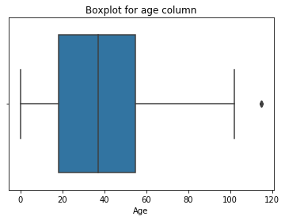

```python
sns.boxplot(x=df.Age);
plt.title("Boxplot for age column");
```

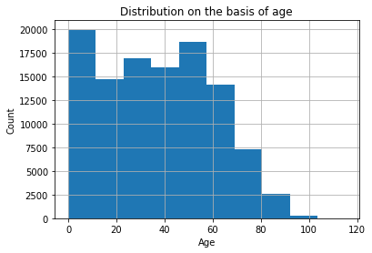

```python
df.Age.hist();
plt.xlabel('Age');
plt.ylabel('Count');
plt.title('Distribution on the basis of age');
```

- The above plotted histogram shows the distribution of ages of people booking their appointments. The above plotted histogram is positively skewed.
- We have choosen age as an column to describe whether the patient would turn up for the appointment or not as age is considerably an important factor in deciding the patients decision for showing up for appointment or not.

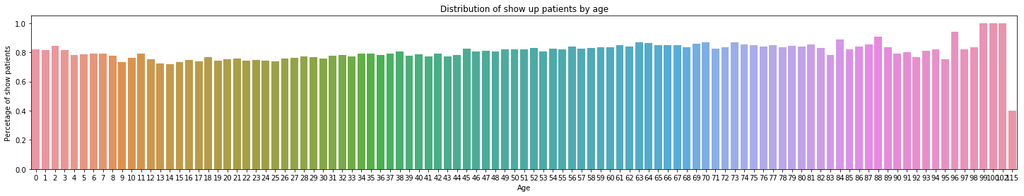

```python
df1=df.groupby(['NoShow','Age']).size()
x=df[df.NoShow == 'No'].groupby(['Age'])
y=df.groupby('Age')
x.size(),y.size()
ratio=x.size()/y.size();
plt.figure(figsize=(25,4))
ax = sns.barplot(x=ratio.index, y=ratio)
plt.ylabel("Percetage of show patients")
plt.title("Distribution of show up patients by age")
plt.show();
```

- From the above visualization we could clearly see that most of the Age group patients have around 80% Show rate

### Show/NoShow Data analysis based on diseases

- Analysis the patients turn up ratio on the basis of their diseases is an important one. The disease from which patient is suffering majorly decides whether they will go for their important or not.

```python
# Defining a function to avoid reptitive code
def graph_analysis(x1,y1,z1,disease):
    graph=sns.countplot(x=x1,hue=y1, data=z1)
    graph.set_title("Show/NoShow for "+disease+" patients")
    plt.show()
```

```python
#defining a function for percentage analysis
def percent_analysis(x1,y1,param):
    ax = sns.barplot(x=x1, y=y1)
    ax.set_title("Show percent for "+param)
    plt.ylabel("Percentage of show patients")
    plt.show()
```

##### 1. Diabetes

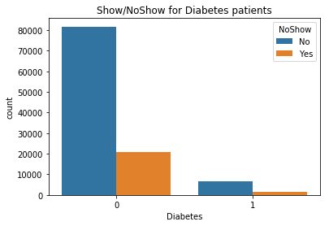

```
Diabetes and NoShow statistics
Diabetes
0    81694
1     6513
dtype: int64
Actual diabetes statistics
Diabetes
0    102583
1      7943
dtype: int64
```

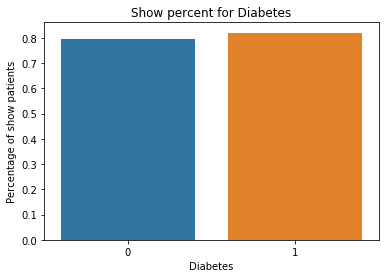

```python
graph_analysis(df.Diabetes,df.NoShow, df, "Diabetes")
x=df[df.NoShow == 'No'].groupby(['Diabetes'])
y=df.groupby('Diabetes')
print('Diabetes and NoShow statistics');
print(x.size());
print('Actual diabetes statistics');
print(y.size());
ratio=x.size()/y.size();
percent_analysis(ratio.index,ratio,"Diabetes")
```

- a) From the above visualization and results we can see that there are around 102,000 patients without Diabetes and out of them around 80% have come for the visit. b) Out of the 8,000 patients with Diabetes around 81% of them have come for the visit.

##### 2. Hypertension

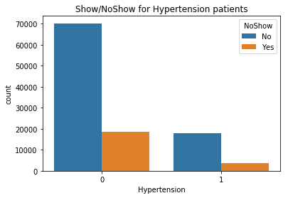

```
Hypertension and NoShow statistics
Hypertension
0    70178
1    18029
dtype: int64
Actual hypertension statistics
Hypertension
0    88725
1    21801
dtype: int64
```

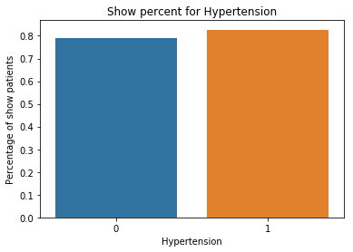

```python
graph_analysis(df.Hypertension,df.NoShow, df,"Hypertension")
x=df[df.NoShow == 'No'].groupby(['Hypertension'])
y=df.groupby('Hypertension')
print('Hypertension and NoShow statistics');
print(x.size());
print('Actual hypertension statistics');
print(y.size());
ratio=x.size()/y.size();
percent_analysis(ratio.index,ratio,"Hypertension")
```

- a) From the above visualization we can see that there are around 88,000 patients without Hypertension and out of them around 79% have come for the visit. b) Out of the 22,000 patients with Hypertension around 82% of them have come for the visit.

##### 3. Alcoholism

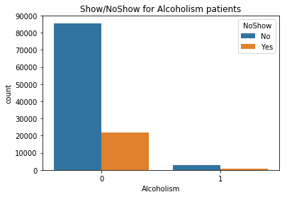

```
Alcoholismm and NoShow statistics
Alcoholism
0    85524
1     2683
dtype: int64
Actual alcoholism statistics
Alcoholism
0    107166
1      3360
dtype: int64
```

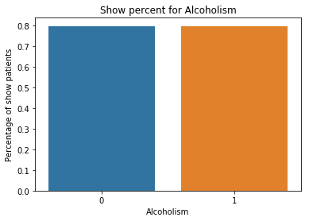

```python
graph_analysis(df.Alcoholism,df.NoShow,df,"Alcoholism")
x=df[df.NoShow == 'No'].groupby(['Alcoholism'])
y=df.groupby('Alcoholism')
print('Alcoholismm and NoShow statistics');
print(x.size());
print('Actual alcoholism statistics');
print(y.size());
ratio=x.size()/y.size();
percent_analysis(ratio.index,ratio,"Alcoholism")
```

- a) From the above visualization we can see that there are around 107,000 patients without Alcoholism and out of them around 80% have come for the visit. b) Out of the 3360 patients with Alcoholism around 80% of them have come for the visit.

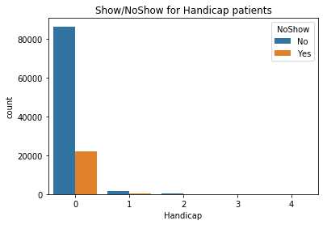

```
Handicap and NoShow statistics
Handicap
0    86373
1     1676
2      146
3       10
4        2
dtype: int64
Actual handicap statistics
Handicap
0    108285
1      2042
2       183
3        13
4         3
dtype: int64
```

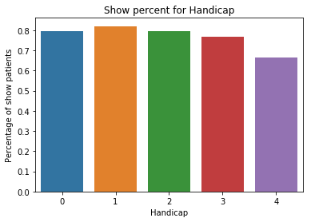

```python
graph_analysis(df.Handicap,df.NoShow,df,"Handicap")
x=df[df.NoShow == 'No'].groupby(['Handicap'])
y=df.groupby('Handicap')
print('Handicap and NoShow statistics');
print(x.size());
print('Actual handicap statistics');
print(y.size());
ratio=x.size()/y.size();
percent_analysis(ratio.index,ratio,"Handicap")
```

- From the above visualization we can see that there are around 110,000 patients without Handicap and out of them around 80% have come for the visit and out of 2000 patients with handicap 82% of patients have turned up for their appointment

### Show/No Show on the basis of gender and SMS

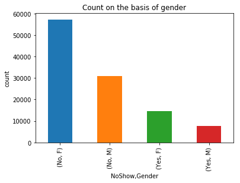

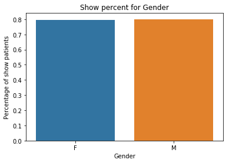

```python
# ON THE BASIS OF GENDER
df1=df.groupby(['NoShow','Gender']).size()
graph=df1.plot(kind="bar")
graph.set_title("Count on the basis of gender")
plt.ylabel('count')
plt.show()
x=df[df.NoShow == 'No'].groupby(['Gender'])
y=df.groupby('Gender')
x.size(),y.size()
ratio=x.size()/y.size();
percent_analysis(ratio.index,ratio,"Gender")
```

- From the above plot and statistics it is clear that the gender booking the most of the appointments is mostly female but the turn up percentages for both male and female is about 80%.
- We have choosen SMS recieved as a criteria to know the show/noshow for patients as there might be some cases patient might tend to forget about their appointment,so sms plays an important role in deciding whether a patient would turn up for the appointment or not.

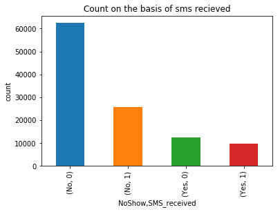

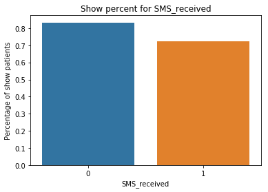

```python
# ON THE BASIS OF SMS_RECIEVED
df1=df.groupby(['NoShow','SMS_received']).size()
graph=df1.plot(kind="bar")
graph.set_title("Count on the basis of sms recieved")
plt.ylabel('count')
plt.show()
x=df[df.NoShow == 'No'].groupby(['SMS_received'])
y=df.groupby('SMS_received')
x.size(),y.size()
ratio=x.size()/y.size();
percent_analysis(ratio.index,ratio,"SMS_received")
```

- From the above statistics and plot it is clear that people didnt recieve sms tend to turn up more in number as compared to those patients who recieved the message.Out of 75000 people who didn't recieve sms 83% of them turn up for their appointment whereas out of 35000 people who recieved sms only 72% of them turned up for their appointment.

## Limitations

> Though the data has no missing and duplicate values, it would be better if we would be given the time for appointment day as we are given the time when the patient has scheduled the time. The given dataset only takes into account only some of the diseases , it would be better if some more diseases are covered The reason for booking the appointment by the patient should also be column, it would help us get a clearer picture of why or why not a patient didn't turn up for the appointmnent

```python
from subprocess import call
call(['python', '-m', 'nbconvert', 'Investigate_a_Dataset.ipynb'])
```

```
0
```